# clustering

```python
import pandas as pd
import numpy as np
%matplotlib inline
from matplotlib import pyplot as plt
from sklearn.cluster import KMeans
from sklearn.preprocessing import StandardScaler
import seaborn as sns
from sklearn.manifold import TSNE
```

Для начала загрузим данные и excelевского файла, правильно проиндексируем по интересуюшему нас критерию "Персона" и кратко взглянем на то, что имеем

```python
xl = pd.ExcelFile("Задача.xlsx")
df = xl.parse("Данные")
df.index = df.Персона
df = df.drop(['Персона'], axis=1)
df.head()
```

| Персона | Возраст, лет | Стаж вождения, лет | Убыточность, % | Уровень заработной платы, руб/год |
| --- | --- | --- | --- | --- |
| 6-LLJEH | 20 | 1 | 263 | 716693 |
| 2-GLHFG | 74 | 51 | 107 | 274393 |
| 6-FJFKL | 27 | 1 | 165 | 723841 |
| 4-KJEJL | 24 | 6 | 348 | 139419 |
| 5-JFFGH | 26 | 3 | 286 | 650003 |

Теперь, когда наши данные загружены, есть два пути - работать с данными как они есть или нормализовать их. Ввиду того, что показатели в разных столбцах имеют разные порядки, то тут стоит выбрать второй случай, а именно нормализвацию данных, которая реализуется при помощи стандартного метода StandardScaler. И только после этого можно будет задавать какой-то вопрос про кластеризацию.  
Первый вопрос, который приходит в голову - это сколько же клатеров у нас получится. Ответ поможет нам найти "метод локтя", применимый для алгоритма KMeans. Подробное описание можно найти тут: [cтатья про кластеризацию на хабре](https://habrahabr.ru/company/ods/blog/325654/). Суть заключается в том, что этот алгоритм минимизирует параметр, называемый *inertia*. Эта самая inertia является дискретной фукцией относительно числа кластеров, и искомое число кластеров достигается в точке, где излом функции максимальный(угол между прозводными слева и справа).  
Также хочется объяснить почему выбран именно KMeans - этот алгоритм самый популярный, а данных у нас немного, поэтому он отлично справится.

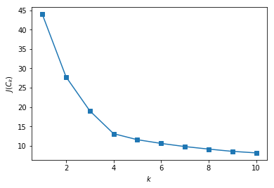

```python
scaler = StandardScaler()
X = scaler.fit_transform(df)
inertia = []
for k in range(1,11):
    kmeans = KMeans(n_clusters=k, random_state=1).fit(X)
    inertia.append(np.sqrt(kmeans.inertia_))

plt.plot(range(1, 11), inertia, marker='s');
plt.xlabel('$k$')
plt.ylabel('$J(C_k)$');
```

Как видно из графика, искомое число кластеров - 4. Обучим наш алгоритм с найденным гиперпараметром. У этого алгортима есть атрибуты *cluster_centers_*, которые показывают, где находятся центры классов, и *labels_*, которые имеет смысл добавить в нашу таблицу к данным. Правда, чтобы понять смысл этих центров, придётся провести обратное отображение.

```python
kmeans = KMeans(n_clusters=4, random_state=1).fit(X)
df['Класс'] = kmeans.labels_
centers = scaler.inverse_transform(kmeans.cluster_centers_)
centers.astype(np.int64)
```

```
array([[     69,      45,     152,  242958],
       [     24,       2,     209,  670466],
       [     56,      29,      65, 2978736],
       [     30,       7,     497,  149292]])
```

```python
df.head()
```

| Персона | Возраст, лет | Стаж вождения, лет | Убыточность, % | Уровень заработной платы, руб/год | Класс |
| --- | --- | --- | --- | --- | --- |
| 6-LLJEH | 20 | 1 | 263 | 716693 | 1 |
| 2-GLHFG | 74 | 51 | 107 | 274393 | 0 |
| 6-FJFKL | 27 | 1 | 165 | 723841 | 1 |
| 4-KJEJL | 24 | 6 | 348 | 139419 | 3 |
| 5-JFFGH | 26 | 3 | 286 | 650003 | 1 |

По большей части задача уже решена, однако есть ещё несколько моментов, которые можно обсудить - дать логические названия классам, посчитать различные характеристики для людей из одного класса и как-нибудь визуализировать результат.

1. Люди пенсионного возраста с большим стажем вождения, со средней убыточностью и живущие на пенсию и прошлые накопления.
2. Молодые люди, недавно закончившие обучения, получили права и устроились на первуб работу. Довольно убыточны, ибо ветер в голове.
3. Люди предпенсионного возраста, как правило с высокой зарплатой и максимально надёжные.
4. Люди, которые впали в кризис среднего возраста, потеряли работу. Крайне убыточные клиенты.

```python
for cluster, sub_df in df.groupby(['Класс']):
    print(sub_df.drop(['Класс'], axis=1).describe())
```

```
       Возраст, лет  Стаж вождения, лет  Убыточность, %  \
count     121.00000          121.000000      121.000000
mean       69.85124           45.826446      152.380165
std         5.68721            6.113752       32.875334
min        59.00000           33.000000       92.000000
25%        65.00000           42.000000      128.000000
50%        70.00000           46.000000      153.000000
75%        74.00000           50.000000      180.000000
max        79.00000           58.000000      209.000000

       Уровень заработной платы, руб/год
count                         121.000000
mean                       242958.446281
std                         24325.309127
min                        200043.000000
25%                        220775.000000
50%                        243203.000000
75%                        267884.000000
max                        279472.000000
       Возраст, лет  Стаж вождения, лет  Убыточность, %  \
count    128.000000          128.000000      128.000000
mean      24.734375            2.835938      209.640625
std        2.968295            1.851908       62.542047
min       20.000000            1.000000      101.000000
25%       22.000000            1.000000      164.000000
50%       25.000000            2.000000      199.000000
75%       27.000000            4.000000      261.500000
max       37.000000           10.000000      337.000000

       Уровень заработной платы, руб/год
count                         128.000000
mean                       670466.312500
std                        136937.394775
min                        139104.000000
25%                        644924.750000
50%                        689903.000000
75%                        742573.250000
max                        799461.000000
       Возраст, лет  Стаж вождения, лет  Убыточность, %  \
count    121.000000          121.000000      121.000000
```

[output cut: 21 more lines]

```
min       22.000000            4.000000      330.000000
25%       25.250000            6.000000      401.000000
50%       30.000000            7.000000      484.000000
75%       34.750000            9.000000      583.750000
max       38.000000           10.000000      700.000000

       Уровень заработной платы, руб/год
count                         114.000000
mean                       149292.008772
std                         17630.238108
min                        120185.000000
25%                        136039.250000
50%                        148532.000000
75%                        163516.500000
max                        179863.000000
```

Исходя из этой статистики можно заявить, что наше предположение про каждый из классов достаточно точно его отражает, разве что последний из классов можно переименовать в просто "безработных", причём чем старше они, тем более убыточны. Да и сами по себе классы получились довольно сбалансированными.

Теперь осталось лишь сделать результаты нагляднее - визуализируем центры наших классов при помощи '*bar*' графиков, и исходное множество при помощи метода *tsne* с числом главных компонет равным 2.

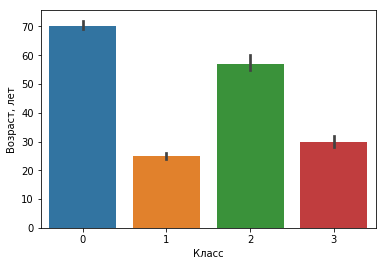

```python
ax = sns.barplot(x="Класс", y="Возраст, лет", data=df, estimator=np.median)
```

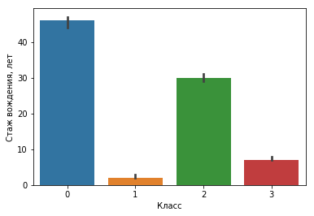

```python
ax = sns.barplot(x="Класс", y="Стаж вождения, лет", data=df, estimator=np.median)
```

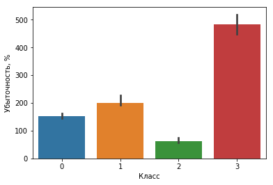

```python
ax = sns.barplot(x="Класс", y="Убыточность, %", data=df, estimator=np.median)
```

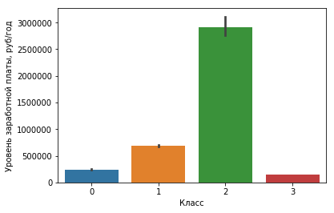

```python
ax = sns.barplot(x="Класс", y="Уровень заработной платы, руб/год", data=df, estimator=np.median)
```

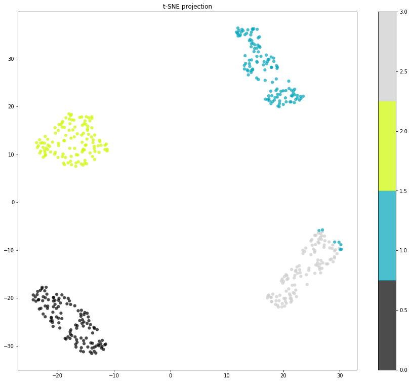

```python
tsne = TSNE(n_components=2, random_state=1)
X_tsne = tsne.fit_transform(X)
plt.figure(figsize=(15,13))
plt.scatter(X_tsne[:, 0], X_tsne[:, 1], c=df.Класс,
            edgecolor='none', alpha=0.7, s=40,
            cmap=plt.cm.get_cmap('nipy_spectral', 4))
plt.colorbar()
plt.title('t-SNE projection');
```

Как видно классы получились хорошо разделимыми, разве что студенты могли причислиться к классу безработных, что довольно логично